# TRGN 510 Final Project: Colon Cancer

# Final Project

## Section 1: Objective

For this project, I will be showing the log2(fold-change) in differential gene expression for RNA-seq data in two subsets of colon cancer: adenocarcinoma and cystic, mucinous and serous neoplasms. The final deliverable will be the the Glimma Vignette. The input files for the Glimma vignette will be HTSeq-count data obtained from The Cancer Genome Atlas Program (TCGA). I will be turning in an HTML containing my R Notebook.

## Section 2: Datasets

### Loading data

Data is obtained from TCGA. I filtered for RNA-Seq experimental strategy, TXT data format and HTSeq-counts workflow type. HTSeq-counts is a tool that quantifies the aligned reads overlapping a gene’s exons. HTSeq data does not have a header, is tab-delimited, the first column is the Ensembl gene ID and the second column is the number of mapped reads of the gene. The counts will be used in differential gene expression analysis using edgeR as the method. To look at the differential gene expression, the counts will be normalized using the calcNormFactors in edgeR and only reads that unambigously map to one gene are used.

### Unit test for data

When data is read in:

```
ENSG00000000003.13
<fctr>
X5290
<int>
ENSG00000000005.5   47
ENSG00000000419.11  1212
ENSG00000000457.12  1176
ENSG00000000460.15  121
ENSG00000000938.11  166
ENSG00000000971.14  1012
ENSG00000001036.12  4401
ENSG00000001084.9   1977
ENSG00000001167.13  976
ENSG00000001460.16  1638
1-10 of 60 rows
```

When dataset is made using the 60 text files:

```
[1] "DGEList"
attr(,"package")
[1] "edgeR"
[1] 60487    60
```

### Unit test for normalized data

Make a box plots of unnormalized and normalized data

```r
par(mfrow=c(1,2))
lcpm <- cpm(x2, log=TRUE)
boxplot(lcpm, las=2, col=col, main="")
title(main="A. Example: Unnormalised data",ylab="Log-cpm")
x2 <- calcNormFactors(x2)
x2$samples$norm.factors
```

[output not shown]

## Proposed Analysis

### Flowchart

```r
library(DiagrammeR)
grViz("digraph flowchart {
      # node definitions with substituted label text
      node [fontname = Helvetica, shape = rectangle]
      tab1 [label = '@@1']
      tab2 [label = '@@2']
      tab3 [label = '@@3']
      tab4 [label = '@@4']
      tab5 [label = '@@5']
      tab6 [label = '@@6']
      tab7 [label = '@@7']
      tab8 [label = '@@8']
      tab9 [label = '@@9']
      tab10 [label = '@@10']

      # edge definitions with the node IDs
      tab1 -> tab2;
      tab2 -> tab3;
      tab3 -> tab4;
      tab4 -> tab8 -> tab5;
      tab4 -> tab5 -> tab6 -> tab7 -> tab9 -> tab10
      }

      [1]: 'Download necessary libraries'
      [2]: 'Load and read datasets'
      [3]: 'Join datasets'
      [4]: 'Unit test: Data was properly loaded?'
      [5]: 'Normalize data'
      [6]: 'Find Mean Varience Trend'
      [7]: 'Analyze DE genes'
      [8]: 'Troubleshoot and fix errors'
      [9]: 'Make Interactive MDS plot'
      [10]: 'Make HeatMap of log-CPM data'
      ")
```

### Loading libraries

```r
library(limma)
library(Glimma)
library(edgeR)
library(Mus.musculus)
library(gplots)
library(RColorBrewer)
```

## Proposed Timeline and Milestones

Week 1: Run the Glimma vignette. I will install the necessary packages in R and understand each step in the vignette.

Week 2: Load in the data (joins, creating datasets) and do a simple, 1 line unit test to look at the data. I will download 60 datasets (30 from each subtype) and join multiple datasets. Emailed Dr. Craig on 11/19 and agreed on turning this milestone in on Sat Nov 23, 2019.

Week 3: Confirm that the data was loaded in correctly and analyze data using the Glimma vignette.Emailed Dr. Craig on 11/26 and agreed on turning this milestone in on 12/1.

Week 4: Troubleshoot for more errors and enhance the user interface.

## User Interface

I anticipate having boxplots, heatmaps, and interactive multi-dimensional scaling (MDS) plots done in an R Notebook. I will submit an HTML page of my completed R Notebook.

### MDS plot

```r
library(limma)
lcpm <- cpm(x, log=TRUE)
par(mfrow=c(1,2))
col.group <- group
levels(col.group) <-  brewer.pal(nlevels(col.group), "Set1")
col.group <- as.character(col.group)
col.lane <- lane
levels(col.lane) <-  brewer.pal(nlevels(col.lane), "Set2")
col.lane <- as.character(col.lane)
plotMDS(lcpm, labels=group, col=col.group)
title(main="A. Sample groups")
plotMDS(lcpm, labels=lane, col=col.lane, dim=c(3,4))
title(main="B. Sequencing lanes")
```

### Make MDS plot interactive

```r
library(glimma)
glMDSPlot(lcpm, labels=paste(group, lane, sep="_"),
          groups=x$samples[,c(2,5)], launch=FALSE)
```

### HeatMap of log-CPM data

```r
library(gplots)
basal.vs.lp.topgenes <- basal.vs.lp$ENTREZID[1:100]
i <- which(v$genes$ENTREZID %in% basal.vs.lp.topgenes)
mycol <- colorpanel(1000,"blue","white","red")
heatmap.2(lcpm[i,], scale="row",
   labRow=v$genes$SYMBOL[i], labCol=group,
   col=mycol, trace="none", density.info="none",
   margin=c(8,6), lhei=c(2,10), dendrogram="column")
```

# Nov 13, 2019

# TRGN 510 Final Project: Milestone 1

# A script for setting up the Glimma Vignette

{ if (!requireNamespace(“BiocManager”, quietly = TRUE)) install.packages(“BiocManager”) BiocManager::install(“limma”) library(limma)

if (!requireNamespace(“BiocManager”, quietly = TRUE)) install.packages(“BiocManager”) BiocManager::install(“Glimma”) library(Glimma)

if (!requireNamespace(“BiocManager”, quietly = TRUE)) install.packages(“BiocManager”)

BiocManager::install(“edgeR”) library(edgeR)

if (!requireNamespace(“BiocManager”, quietly = TRUE)) install.packages(“BiocManager”)

BiocManager::install(“Mus.musculus”) library(Mus.musculus)

library(R.utils)

if (!requireNamespace(“BiocManager”, quietly = TRUE)) install.packages(“BiocManager”)

BiocManager::install(“CAMERA”) library(CAMERA) }

# Data Packaging

## Reading in count data

```r
library(R.utils)
url <- "https://www.ncbi.nlm.nih.gov/geo/download/?acc=GSE63310&format=file"
utils::download.file(url, destfile="GSE63310_RAW.tar", mode="wb")
utils::untar("GSE63310_RAW.tar", exdir = ".")
files <- c("GSM1545535_10_6_5_11.txt", "GSM1545536_9_6_5_11.txt", "GSM1545538_purep53.txt",
  "GSM1545539_JMS8-2.txt", "GSM1545540_JMS8-3.txt", "GSM1545541_JMS8-4.txt",
  "GSM1545542_JMS8-5.txt", "GSM1545544_JMS9-P7c.txt", "GSM1545545_JMS9-P8c.txt")
for(i in paste(files, ".gz", sep=""))
  R.utils::gunzip(i, overwrite=TRUE)
files <- c("GSM1545535_10_6_5_11.txt", "GSM1545536_9_6_5_11.txt",
"GSM1545538_purep53.txt", "GSM1545539_JMS8-2.txt",
   "GSM1545540_JMS8-3.txt", "GSM1545541_JMS8-4.txt",
   "GSM1545542_JMS8-5.txt", "GSM1545544_JMS9-P7c.txt",
   "GSM1545545_JMS9-P8c.txt")
read.delim(files[1], nrow=5)
```

| EntrezID | GeneLength | Count |
| --- | --- | --- |
| 497097 | 3634 | 1 |
| 100503874 | 3259 | 0 |
| 100038431 | 1634 | 0 |
| 19888 | 9747 | 0 |
| 20671 | 3130 | 1 |

## Reading the 9 text files into R and combining into a matrix of counts

```r
library(edgeR)
x <- readDGE(files, columns=c(1,3))
class(x)
```

```
[1] "DGEList"
attr(,"package")
[1] "edgeR"
```

```r
dim(x)
```

```
[1] 27179     9
```

```r
names(x)
```

```
[1] "samples" "counts"
```

```r
str(x)
```

```
Formal class 'DGEList' [package "edgeR"] with 1 slot
  ..@ .Data:List of 2
  .. ..$ :'data.frame': 9 obs. of  4 variables:
  .. .. ..$ files       : chr [1:9] "GSM1545535_10_6_5_11.txt" "GSM1545536_9_6_5_11.txt" "GSM1545538_purep53.txt" "GSM1545539_JMS8-2.txt" ...
  .. .. ..$ group       : Factor w/ 1 level "1": 1 1 1 1 1 1 1 1 1
  .. .. ..$ lib.size    : num [1:9] 32863052 35335491 57160817 51368625 75795034 ...
  .. .. ..$ norm.factors: num [1:9] 1 1 1 1 1 1 1 1 1
  .. ..$ : num [1:27179, 1:9] 1 0 0 0 1 431 768 4 810 452 ...
  .. .. ..- attr(*, "dimnames")=List of 2
  .. .. .. ..$ Tags   : chr [1:27179] "497097" "100503874" "100038431" "19888" ...
  .. .. .. ..$ Samples: chr [1:9] "GSM1545535_10_6_5_11" "GSM1545536_9_6_5_11" "GSM1545538_purep53" "GSM1545539_JMS8-2" ...
```

## Annotate the samples

```r
x$samples
```

|  | files | group | lib.size | norm.factors |
| --- | --- | --- | --- | --- |
| GSM1545535_10_6_5_11 | GSM1545535_10_6_5_11.txt | 1 | 32863052 | 1 |
| GSM1545536_9_6_5_11 | GSM1545536_9_6_5_11.txt | 1 | 35335491 | 1 |
| GSM1545538_purep53 | GSM1545538_purep53.txt | 1 | 57160817 | 1 |
| GSM1545539_JMS8-2 | GSM1545539_JMS8-2.txt | 1 | 51368625 | 1 |
| GSM1545540_JMS8-3 | GSM1545540_JMS8-3.txt | 1 | 75795034 | 1 |
| GSM1545541_JMS8-4 | GSM1545541_JMS8-4.txt | 1 | 60517657 | 1 |
| GSM1545542_JMS8-5 | GSM1545542_JMS8-5.txt | 1 | 55086324 | 1 |
| GSM1545544_JMS9-P7c | GSM1545544_JMS9-P7c.txt | 1 | 21311068 | 1 |
| GSM1545545_JMS9-P8c | GSM1545545_JMS9-P8c.txt | 1 | 19958838 | 1 |

## Organizing sample information

```r
library(edgeR)
samplenames <- substring(colnames(x), 12, nchar(colnames(x)))
samplenames
```

```
[1] "10_6_5_11" "9_6_5_11"  "purep53"   "JMS8-2"    "JMS8-3"    "JMS8-4"
[7] "JMS8-5"    "JMS9-P7c"  "JMS9-P8c"
```

```r
colnames(x) <- samplenames
group <- as.factor(c("LP", "ML", "Basal", "Basal", "ML", "LP",
                     "Basal", "ML", "LP"))
x$samples$group <- group
lane <- as.factor(rep(c("L004","L006","L008"), c(3,4,2)))
x$samples$lane <- lane
x$samples
```

|  | files | group | lib.size | norm.factors | lane |
| --- | --- | --- | --- | --- | --- |
| 10_6_5_11 | GSM1545535_10_6_5_11.txt | LP | 32863052 | 1 | L004 |
| 9_6_5_11 | GSM1545536_9_6_5_11.txt | ML | 35335491 | 1 | L004 |
| purep53 | GSM1545538_purep53.txt | Basal | 57160817 | 1 | L004 |
| JMS8-2 | GSM1545539_JMS8-2.txt | Basal | 51368625 | 1 | L006 |
| JMS8-3 | GSM1545540_JMS8-3.txt | ML | 75795034 | 1 | L006 |
| JMS8-4 | GSM1545541_JMS8-4.txt | LP | 60517657 | 1 | L006 |
| JMS8-5 | GSM1545542_JMS8-5.txt | Basal | 55086324 | 1 | L006 |
| JMS9-P7c | GSM1545544_JMS9-P7c.txt | ML | 21311068 | 1 | L008 |
| JMS9-P8c | GSM1545545_JMS9-P8c.txt | LP | 19958838 | 1 | L008 |

## Organizing gene annotations

```r
library(Mus.musculus)
geneid <- rownames(x)
genes <- select(Mus.musculus, keys=geneid, columns=c("SYMBOL", "TXCHROM"),
                keytype="ENTREZID")
head(genes)
```

|  | ENTREZID | SYMBOL | TXCHROM |
| --- | --- | --- | --- |
| 1 | 497097 | Xkr4 | chr1 |
| 2 | 100503874 | Gm19938 | NA |
| 3 | 100038431 | Gm10568 | NA |
| 4 | 19888 | Rp1 | chr1 |
| 5 | 20671 | Sox17 | chr1 |
| 6 | 27395 | Mrpl15 | chr1 |

## Resolve duplicate gene IDs

```r
library(Mus.musculus)
genes <- genes[!duplicated(genes$ENTREZID),]
```

## Package in a DGEList-object containing raw count data with associated sample information and gene annotations

```r
library(Mus.musculus)
x$genes <- genes
x
```

# Data Pre-processing

## Transformations from the raw-scale: convert raw counts to counts per million (CPM) and log2-counts per million (log-CPM)

```r
library(edgeR)
cpm <- cpm(x)
lcpm <- cpm(x, log=TRUE)
L <- mean(x$samples$lib.size) * 1e-6
M <- median(x$samples$lib.size) * 1e-6
c(L, M)
summary(lcpm)
```

## Remove lowly expressed genes

```r
library(edgeR)
table(rowSums(x$counts==0)==9)
```

## Filter genes while keeping as many genes as possible with worthwile counts

```r
library(edgeR)
keep.exprs <- filterByExpr(x, group=group)
x <- x[keep.exprs,, keep.lib.sizes=FALSE]
dim(x)
```

## Plot the density of log-CPM values for raw and filtered data

```r
lcpm.cutoff <- log2(10/M + 2/L)
library(RColorBrewer)
nsamples <- ncol(x)
col <- brewer.pal(nsamples, "Paired")
par(mfrow=c(1,2))
plot(density(lcpm[,1]), col=col[1], lwd=2, ylim=c(0,0.26), las=2, main="", xlab="")
title(main="A. Raw data", xlab="Log-cpm")
abline(v=lcpm.cutoff, lty=3)
for (i in 2:nsamples){
den <- density(lcpm[,i])
lines(den$x, den$y, col=col[i], lwd=2)
}
legend("topright", samplenames, text.col=col, bty="n")
lcpm <- cpm(x, log=TRUE)
plot(density(lcpm[,1]), col=col[1], lwd=2, ylim=c(0,0.26), las=2, main="", xlab="")
title(main="B. Filtered data", xlab="Log-cpm")
abline(v=lcpm.cutoff, lty=3)
for (i in 2:nsamples){
den <- density(lcpm[,i])
lines(den$x, den$y, col=col[i], lwd=2)
}
legend("topright", samplenames, text.col=col, bty="n")
```

## Normalising gene expression distributions

```r
library(edgeR)
x <- calcNormFactors(x, method = "TMM")
x$samples$norm.factors
```

## Improve visualization by duplicating data then adjusting the counts

```r
x2 <- x
x2$samples$norm.factors <- 1
x2$counts[,1] <- ceiling(x2$counts[,1]*0.05)
x2$counts[,2] <- x2$counts[,2]*5
```

## Boxplot expression distribution of samples for normalised and unnormalised data

```r
par(mfrow=c(1,2))
lcpm <- cpm(x2, log=TRUE)
boxplot(lcpm, las=2, col=col, main="")
title(main="A. Example: Unnormalised data",ylab="Log-cpm")
x2 <- calcNormFactors(x2)
x2$samples$norm.factors
lcpm <- cpm(x2, log=TRUE)
boxplot(lcpm, las=2, col=col, main="")
title(main="B. Example: Normalised data",ylab="Log-cpm")
```

## Unsupervised clustering of cells: make multi-dimensional scaling plot (MDS) to show simmilarities and dissimilarities between samples in an unsupervised manner

```r
library(limma)
lcpm <- cpm(x, log=TRUE)
par(mfrow=c(1,2))
col.group <- group
levels(col.group) <-  brewer.pal(nlevels(col.group), "Set1")
col.group <- as.character(col.group)
col.lane <- lane
levels(col.lane) <-  brewer.pal(nlevels(col.lane), "Set2")
col.lane <- as.character(col.lane)
plotMDS(lcpm, labels=group, col=col.group)
title(main="A. Sample groups")
plotMDS(lcpm, labels=lane, col=col.lane, dim=c(3,4))
title(main="B. Sequencing lanes")
```

## Make interactive using Glimma, html page will be generarted and opened in a browser if launch=TRUE

```r
library(Glimma)
glMDSPlot(lcpm, labels=paste(group, lane, sep="_"),
          groups=x$samples[,c(2,5)], launch=FALSE)
```

# Differential Expression Analysis

## Creating a design matrix

```r
design <- model.matrix(~0+group+lane)
colnames(design) <- gsub("group", "", colnames(design))
design
```

## Contrasts for pairwise comparisons between cell populations

```r
library(Glimma)
contr.matrix <- makeContrasts(
   BasalvsLP = Basal-LP,
   BasalvsML = Basal - ML,
   LPvsML = LP - ML,
   levels = colnames(design))
contr.matrix
```

## Remove heteroscedascity from count data

```r
library(Glimma)
par(mfrow=c(1,2))
v <- voom(x, design, plot=TRUE)
v
```

## Apply voom precision weights to data

```r
vfit <- lmFit(v, design)
vfit <- contrasts.fit(vfit, contrasts=contr.matrix)
efit <- eBayes(vfit)
plotSA(efit, main="Final model: Mean-variance trend")
```

## Examine the number of DE genes

```r
summary(decideTests(efit))
```

## Set a minimum log-fold change(log-FC) of 1

```r
tfit <- treat(vfit, lfc=1)
dt <- decideTests(tfit)
summary(dt)
```

## Extract genes that are DE in multiple comparisons

```r
de.common <- which(dt[,1]!=0 & dt[,2]!=0)
length(de.common)
head(tfit$genes$SYMBOL[de.common], n=20)
vennDiagram(dt[,1:2], circle.col=c("turquoise", "salmon"))
```

## Extract and write results for all 3 comparisons (basalvsLP, basalvsML, and LPvsML) to a single output file

```r
write.fit(tfit, dt, file="results.txt")
```

## Examining individual DE genes from top to bottom

```r
basal.vs.lp <- topTreat(tfit, coef=1, n=Inf)
basal.vs.ml <- topTreat(tfit, coef=2, n=Inf)
head(basal.vs.lp)
```

```r
head(basal.vs.ml)
```

## Summarize results for genes using mean-difference plots that highlight differentially expressed genes

```r
plotMD(tfit, column=1, status=dt[,1], main=colnames(tfit)[1],
       xlim=c(-8,13))
```

## Make interactive mean-difference plot. To open html page in a browser make launch=TRUE

```r
glMDPlot(tfit, coef=1, status=dt, main=colnames(tfit)[1],         side.main="ENTREZID", counts=lcpm, groups=group, launch=TRUE)
```

## Make heatmap

```r
library(gplots)
basal.vs.lp.topgenes <- basal.vs.lp$ENTREZID[1:100]
i <- which(v$genes$ENTREZID %in% basal.vs.lp.topgenes)
mycol <- colorpanel(1000,"blue","white","red")
heatmap.2(lcpm[i,], scale="row",
   labRow=v$genes$SYMBOL[i], labCol=group,
   col=mycol, trace="none", density.info="none",
   margin=c(8,6), lhei=c(2,10), dendrogram="column")
```

# Gene set testing by applying the camera method on c2 gene signatures from the Broad Institute’s MSigDB c2 collection

```r
load("/Users/ashleynoriega/Downloads/mouse_c2_v5p2.rdata")
idx <- ids2indices(Mm.c2,id=rownames(v))
cam.BasalvsLP <- camera(v,idx,design,contrast=contr.matrix[,1])
head(cam.BasalvsLP,5)
cam.BasalvsML <- camera(v,idx,design,contrast=contr.matrix[,2])
head(cam.BasalvsML,5)
cam.LPvsML <- camera(v,idx,design,contrast=contr.matrix[,3])
head(cam.LPvsML,5)
```

```r
barcodeplot(efit$t[,3], index=idx$LIM_MAMMARY_LUMINAL_MATURE_UP,
            index2=idx$LIM_MAMMARY_LUMINAL_MATURE_DN, main="LPvsML")
```

# Nov 20, 2019

# TRGN 510 Final Project: Milestone 2

# Loading in RNA seq colon cancer data from TCGA

## RNASeq files for cystic, mucinous, and serous neoplasms and adenocarcinoma

I created a new folder called COAD and stored all 60 files in it. I then changed them to TXT files and opened them.

# Data Packaging

## The urls for the 30 files I downloaded locally for cystic, mucinous and serous colon cancer

1. https://portal.gdc.cancer.gov/files/536f5a77-0087-457d-ac95-6d1a9abad8cb, UUID 536f5a77-0087-457d-ac95-6d1a9abad8cb, case: TCGA-AA-3516
2. https://portal.gdc.cancer.gov/files/ed52de66-66fa-44ce-b679-cf641b0d92cd, UUID ed52de66-66fa-44ce-b679-cf641b0d92cd, case: TCGA-AA-3516
3. https://portal.gdc.cancer.gov/files/b28090c5-c42d-4836-9bb1-ce906d3ead95, UUID: b28090c5-c42d-4836-9bb1-ce906d3ead95, case TCGA-AA-3854
4. https://portal.gdc.cancer.gov/cases/57cdaa1c-4e94-4a28-ab3b-300c0457555f, UUID: 49e29c69-d9d7-4496-9f24-26f42c8b6d8e, case: TCGA-A6-2674
5. https://portal.gdc.cancer.gov/files/08ed32e4-fb94-4bc0-8715-83ee2143a13d, UUID: 08ed32e4-fb94-4bc0-8715-83ee2143a13d, case: TCGA-AA-A00J
6. https://portal.gdc.cancer.gov/files/6e571f71-d5fb-42f3-a35b-554c5ab76587, UUID: 6e571f71-d5fb-42f3-a35b-554c5ab76587, case: TCGA-AA-A01G
7. https://portal.gdc.cancer.gov/files/8b12a000-f588-4a78-a9eb-f06041a65789, UUID: 8b12a000-f588-4a78-a9eb-f06041a65789, case: TCGA-A6-6780
8. https://portal.gdc.cancer.gov/files/02734d4d-fc8f-4ef7-ac82-1b4d7184cc5e, UUID: 02734d4d-fc8f-4ef7-ac82-1b4d7184cc5e, case: TCGA-CK-4950
9. https://portal.gdc.cancer.gov/files/6466a8b1-d1e2-4195-a353-0800576c13c8, UUID: 6466a8b1-d1e2-4195-a353-0800576c13c8, case: TCGA-G4-6322
10. https://portal.gdc.cancer.gov/files/bc47f01c-1994-4ff8-a356-94d9679b66ee, UUID: bc47f01c-1994-4ff8-a356-94d9679b66ee, case: TCGA-AA-3947
11. https://portal.gdc.cancer.gov/files/b045ee79-82a6-4636-a875-1a58603d89ff, UUID: b045ee79-82a6-4636-a875-1a58603d89ff, case: TCGA-A6-A566
12. https://portal.gdc.cancer.gov/files/c383ba2c-b00a-4bd2-82cb-b3f04c2a8172, UUID: c383ba2c-b00a-4bd2-82cb-b3f04c2a8172, case: TCGA-AA-3877
13. https://portal.gdc.cancer.gov/files/b52775aa-273e-484e-82c7-c625f09415fa, UUID: b52775aa-273e-484e-82c7-c625f09415fa, case: TCGA-A6-3809
14. https://portal.gdc.cancer.gov/files/7b15a87a-805c-4b8a-84de-549cec9c44e3, UUID: 7b15a87a-805c-4b8a-84de-549cec9c44e3, case: TCGA-AA-3684
15. https://portal.gdc.cancer.gov/files/b4f3dbbb-2686-4896-9e60-5bef6c9150b4, UUID: b4f3dbbb-2686-4896-9e60-5bef6c9150b4, case: TCGA-AA-3692
16. https://portal.gdc.cancer.gov/files/0b16e2bd-3ec7-4901-9ff0-a389670e5019, UUID: 0b16e2bd-3ec7-4901-9ff0-a389670e5019, case: TCGA-D5-6534
17. https://portal.gdc.cancer.gov/files/a6690007-f347-49c3-a0ba-28e01d131971, UUID: a6690007-f347-49c3-a0ba-28e01d131971, case: TCGA-A6-3809
18. https://portal.gdc.cancer.gov/files/a1742cf6-c3c5-43e7-879c-489494460e78, UUID: a1742cf6-c3c5-43e7-879c-489494460e78, case: TCGA-AA-A00N
19. https://portal.gdc.cancer.gov/files/d5be795d-beb6-4def-bda8-f485ee45bfc1, UUID: d5be795d-beb6-4def-bda8-f485ee45bfc1, case: TCGA-A6-2674
20. https://portal.gdc.cancer.gov/files/46306072-c59c-4b4b-963c-9c4e778ff34b, UUID: 46306072-c59c-4b4b-963c-9c4e778ff34b, case: TCGA-A6-6780
21. https://portal.gdc.cancer.gov/files/a938cb2c-c8e8-4395-915b-37e1e279a4da, UUID: a938cb2c-c8e8-4395-915b-37e1e279a4da, case: TCGA-G4-6302
22. https://portal.gdc.cancer.gov/files/7fec7c90-fd2e-4ee2-ba1a-77f85920771f, UUID: 7fec7c90-fd2e-4ee2-ba1a-77f85920771f, case: TCGA-DM-A282
23. https://portal.gdc.cancer.gov/files/2c3fd34c-70d1-4331-9628-260b77329b53, UUID: 2c3fd34c-70d1-4331-9628-260b77329b53, case: TCGA-F4-6704
24. https://portal.gdc.cancer.gov/files/4168a720-521e-47ff-afb5-4abe3e815490, UUID: 4168a720-521e-47ff-afb5-4abe3e815490, case: TCGA-AA-3950
25. https://portal.gdc.cancer.gov/files/ecc90bd1-f594-41ea-ba4b-d42f4c64880b, UUID: ecc90bd1-f594-41ea-ba4b-d42f4c64880b, case: TCGA-A6-6781
26. https://portal.gdc.cancer.gov/files/8736ed27-2141-48d9-b677-b1a0e14d4b50, UUID: 8736ed27-2141-48d9-b677-b1a0e14d4b50, case: TCGA-CA-6717
27. https://portal.gdc.cancer.gov/files/3b8d04cd-d658-46ba-adca-079fee531e17, UUID: 3b8d04cd-d658-46ba-adca-079fee531e17, case: TCGA-AA-3821
28. https://portal.gdc.cancer.gov/files/b27da518-d023-4f9c-a9ab-5cd68ee37870, UUID: b27da518-d023-4f9c-a9ab-5cd68ee37870, case: TCGA-CK-4951
29. https://portal.gdc.cancer.gov/files/e7005df6-f78b-4e47-abe7-61ae6a2ee026, UUID: e7005df6-f78b-4e47-abe7-61ae6a2ee026, case: TCGA-AA-A01R
30. https://portal.gdc.cancer.gov/files/e3598d14-292c-41cc-9b59-4497fa078272, UUID: e3598d14-292c-41cc-9b59-4497fa078272, case: TCGA-D5-6930

## The urls for the 30 files adenocarcinoma I downloaded locally for adenocarcinoma

1. https://portal.gdc.cancer.gov/files/f1185347-ad15-43ae-9ef3-d5343b31a0fc, UUID: f1185347-ad15-43ae-9ef3-d5343b31a0fc, case: TCGA-A6-6654
2. https://portal.gdc.cancer.gov/files/0d53cb1c-97c4-4088-9e43-029de88fd66d, UUID: 0d53cb1c-97c4-4088-9e43-029de88fd66d, case: TCGA-DM-A1D4
3. https://portal.gdc.cancer.gov/files/a74bbce0-7f3d-434e-b294-7fa45e5b3a60, UUID: a74bbce0-7f3d-434e-b294-7fa45e5b3a60, case: TCGA-A6-2684
4. https://portal.gdc.cancer.gov/files/47554e4e-cd13-4b92-80be-e1940f9a950f, UUID: 47554e4e-cd13-4b92-80be-e1940f9a950f, case: TCGA-A6-5657
5. https://portal.gdc.cancer.gov/files/de60dbd7-8a93-47a5-b1ea-a3f95beade8a, UUID: de60dbd7-8a93-47a5-b1ea-a3f95beade8a, case: TCGA-F4-6854
6. https://portal.gdc.cancer.gov/files/70883b31-d130-4efd-a7c6-169c8d4a253d, UUID: 70883b31-d130-4efd-a7c6-169c8d4a253d, case: TCGA-AD-A5EJ
7. https://portal.gdc.cancer.gov/files/042bda3d-77aa-4522-8a97-c121711a760e, UUID: 042bda3d-77aa-4522-8a97-c121711a760e, case: TCGA-AG-3582
8. https://portal.gdc.cancer.gov/files/b6388e09-7ed5-4041-97bb-4427ba5571ba, UUID: b6388e09-7ed5-4041-97bb-4427ba5571ba, case: TCGA-AY-6197
9. https://portal.gdc.cancer.gov/files/54394c0b-6ae3-4b48-8e89-350ad5349611, UUID: 54394c0b-6ae3-4b48-8e89-350ad5349611, case: TCGA-AA-3554
10. https://portal.gdc.cancer.gov/files/f7e21d61-19b6-4e99-887f-463d4419628c, UUID: f7e21d61-19b6-4e99-887f-463d4419628c, case: TCGA-AG-4015
11. https://portal.gdc.cancer.gov/files/b4114885-38cd-4e8a-874b-b78da8d95e2c, UUID: b4114885-38cd-4e8a-874b-b78da8d95e2c, case: TCGA-CM-6171
12. https://portal.gdc.cancer.gov/files/f9fda40d-67e4-4cb9-859c-ddc2ea84b7e4, UUID: f9fda40d-67e4-4cb9-859c-ddc2ea84b7e4, case: TCGA-CM-6170
13. https://portal.gdc.cancer.gov/files/b4aebb2a-d0b8-43d8-bd1f-78af2065d8f9, UUID: b4aebb2a-d0b8-43d8-bd1f-78af2065d8f9, case: TCGA-AA-3846
14. https://portal.gdc.cancer.gov/files/6a750710-5ed9-4d24-b2bf-3a4e3211878f, UUID: 6a750710-5ed9-4d24-b2bf-3a4e3211878f, case: TCGA-CM-6677
15. https://portal.gdc.cancer.gov/files/93d1a78f-423e-4560-b4d3-ee4a89ac922b, UUID: 93d1a78f-423e-4560-b4d3-ee4a89ac922b, case: TCGA-RU-A8FL
16. https://portal.gdc.cancer.gov/files/2e632fd9-fa17-4290-9601-a5d462cf152c, UUID: 2e632fd9-fa17-4290-9601-a5d462cf152c, case: TCGA-AZ-4323
17. https://portal.gdc.cancer.gov/files/7239b026-2587-489d-81fe-7bc657b7523c, UUID: 7239b026-2587-489d-81fe-7bc657b7523c, case: TCGA-CM-6164
18. https://portal.gdc.cancer.gov/files/90e86a26-fffa-4c38-b2e0-bf0704ee3615, UUID: 90e86a26-fffa-4c38-b2e0-bf0704ee3615, case: TCGA-AZ-4315
19. https://portal.gdc.cancer.gov/files/9ff11fe0-037c-405e-95c3-dc4a15413db8, UUID: 9ff11fe0-037c-405e-95c3-dc4a15413db8, case: TCGA-G4-6311
20. https://portal.gdc.cancer.gov/files/b8eed826-6051-4358-9b3d-44d1553dd9ad, UUID: b8eed826-6051-4358-9b3d-44d1553dd9ad, case: TCGA-AA-3522
21. https://portal.gdc.cancer.gov/files/c172bc07-d4f0-41be-a558-49abc81065c2, UUID: c172bc07-d4f0-41be-a558-49abc81065c2, case: TCGA-AA-3667
22. https://portal.gdc.cancer.gov/files/260edc5e-1ca6-4b07-b96d-59594d03ac54, UUID: 260edc5e-1ca6-4b07-b96d-59594d03ac54, case: TCGA-AA-A00U
23. https://portal.gdc.cancer.gov/files/0c5c1a38-7e9c-4b43-810d-0761c3af49b1, UUID: 0c5c1a38-7e9c-4b43-810d-0761c3af49b1, case: TCGA-AA-3506
24. https://portal.gdc.cancer.gov/files/7024ba0c-be56-4907-9254-cdb2579e536e, UUID: 7024ba0c-be56-4907-9254-cdb2579e536e, case: TCGA-NH-A8F7
25. https://portal.gdc.cancer.gov/files/031cf2a5-74e0-4b5f-98bd-da60628c0854, UUID: 031cf2a5-74e0-4b5f-98bd-da60628c0854, case: TCGA-AA-3680
26. https://portal.gdc.cancer.gov/files/91991ecf-cc54-4110-8a4e-9236bf8aa072, UUID: 91991ecf-cc54-4110-8a4e-9236bf8aa072, case: TCGA-A6-4105
27. https://portal.gdc.cancer.gov/files/47aceec1-a01d-419f-9689-c46284c79bcb, UUID: 47aceec1-a01d-419f-9689-c46284c79bcb, case: TCGA-D5-6922
28. https://portal.gdc.cancer.gov/files/ce84c955-63db-473a-a6d7-0e3daad6efd4, UUID: ce84c955-63db-473a-a6d7-0e3daad6efd4, case: TCGA-AA-3524
29. https://portal.gdc.cancer.gov/files/a071fc45-61ea-4815-93bf-be34980e59ee, UUID: a071fc45-61ea-4815-93bf-be34980e59ee, case: TCGA-AA-3855
30. https://portal.gdc.cancer.gov/files/8b275144-b885-4fb0-af39-fea1e48a970a, UUID: 8b275144-b885-4fb0-af39-fea1e48a970a, case: TCGA-AA-A00Q

## Load in count data

First rename the “.count” files to “.txt” and unzip each one by opening each file

```r
setwd('~/Desktop/COAD_Data/')
```

```
The working directory was changed to /Users/ashleynoriega/Desktop/COAD_Data inside a notebook chunk. The working directory will be reset when the chunk is finished running. Use the knitr root.dir option in the setup chunk to change the working directory for notebook chunks.
```

```r
COAD_files <- c("9e8b528b-1172-4c07-a09b-ebb23cf2310c.htseq.txt", "bda1a9a4-a14f-4463-81d2-a4fcca65d6f1.htseq.txt",
   "5697212f-b3fd-479f-84b0-ec0aae54534a.htseq.txt", "7f9a629b-12ed-48cc-8d5c-1c2f5db9cf1f.htseq.txt",
   "15864159-be88-41c8-bdef-c2c5927cb1a1.htseq.txt", "649b19e1-96e2-4b55-951d-3b6ee9f4b91f.htseq.txt",
   "86679663-dfc5-46ad-8cf9-c7954c4b339b.htseq.txt", "28004569-048d-4f8c-99aa-7a8c69a98dcc.htseq.txt",                 "911f6378-8a25-4570-9d3b-80f5b5bfc085.htseq.txt", "d5dca54e-d7e9-4328-b2ca-1d191a2b8b4c.htseq.txt",                 "f3895ae4-1228-49b3-9342-3c3b86cb5243.htseq.txt", "f590941d-19dc-427a-95b6-942c97ea8333.htseq.txt",                 "55aa6d16-3598-42ca-8844-0fe84739ef66.htseq.txt", "0e7094cf-4c79-43f4-8b72-9de259e5e18f.htseq.txt",                 "9a62fe1f-36ec-4e8e-b3d9-bdfc62f71905.htseq.txt", "d2587070-cb7d-440d-ae49-52f5077248e6.htseq.txt",                 "7800bdb2-aa8b-43e0-8e45-1b968872b34e.htseq.txt", "2bcd2efd-4fd6-40ee-86a4-867ae82711b0.htseq.txt",                 "424d8e5f-9fc6-470b-ad2c-b4447b0eb07e.htseq.txt", "934f9dc6-1260-4268-b022-870f1e37dd6f.htseq.txt",                 "0fa55c0e-6f8f-44a6-82fe-9a42495d3484.htseq.txt", "c8544a8a-4352-438d-94d4-3495af2e9a78.htseq.txt",                 "dade0b16-ecc3-43b3-b328-3819a8fc18c6.htseq.txt", "e875ae4e-4645-4e84-b0ff-9c9a694717a9.htseq.txt",                 "debd6982-7c27-42e8-b778-20afcc78a5f3.htseq.txt", "17c88994-9e8e-4f16-8c41-34e98a0d8c52.htseq.txt",                 "7f5a924a-ddf3-45ff-be1f-5b5909305f46.htseq.txt", "fa73bdce-67fb-42aa-883f-635f0e7bcdc6.htseq.txt",                 "abe20df7-6b97-4397-8864-881bac27e92c.htseq.txt", "62f84581-4c7d-4c8e-835c-9304bcec3106.htseq.txt", "3abbd2b5-04db-4fe0-8dd1-ea2b48caa4c1.htseq.txt", "087666cd-47ae-4f56-b947-d6aa1c25e8a7.htseq.txt",
   "c14f98e2-8e9b-49f4-a244-3d06c6cb7126.htseq.txt", "13abc91e-fbfc-4c55-bf54-fbd134979ccc.htseq.txt",
   "6ae2dd6c-2a39-411f-a1fc-11e0e6e82165.htseq.txt", "8f77f4f4-b184-40c7-8ab8-2f95b13620b5.htseq.txt",
   "168e5cb2-7390-45ad-ad04-c9aa4416e950.htseq.txt", "0ed65bdf-cb92-47c1-8aeb-42518ce639b8.htseq.txt",                 "4e7c6811-88e4-4bb7-a88f-7491dfa6d072.htseq.txt", "7fb73a84-867a-4c28-aa02-93068efffb7b.htseq.txt",                 "b53f9a9d-b24d-410d-b3e9-f2a8bf22ca27.htseq.txt", "f7ce175f-763e-4a55-97e3-0381d889b0eb.htseq.txt",                 "f346f2d2-285c-455c-ba34-ea8eec3fa881.htseq.txt", "e53e1a83-1979-4e12-bbb7-79b37d0cfe03.htseq.txt",                 "a26d49db-2309-46a0-a3ed-275378d484e7.htseq.txt", "a3f88a5d-7169-465b-bb80-e5999590681c.htseq.txt",                 "c264fe3b-482b-44ec-83a4-73df565663ff.htseq.txt", "bd2dfab3-88a8-4673-ba36-3daf252d0b4d.htseq.txt",                 "7261b656-c79c-4581-a503-15b653e2b5d2.htseq.txt", "ee4dcccc-514b-4cc6-ae63-6ed3e7519a40.htseq.txt",                 "f596eabc-e39a-4e35-9fc6-edade04eb785.htseq.txt", "bf9c448b-bdc9-4f74-b13a-374e6add7939.htseq.txt",                 "564daa81-cfef-45b6-94a0-3249b2724d9b.htseq.txt", "82e00e45-734c-471f-ba97-79ec3b7e0baa.htseq.txt",                 "9c52ed00-325f-4664-8873-327bcaa5ea74.htseq.txt", "fabefb10-5546-4017-8ea1-29982a10fb3c.htseq.txt",                 "32a115cf-570f-4ad9-a123-8e1970062f51.htseq.txt", "05eef9f8-a246-403a-b0be-07d274b6f93a.htseq.txt",                 "5c18c6a8-9ad2-43a8-a3a0-83d8fc0cc257.htseq.txt", "43b292be-5d63-4523-a43f-666d20039208.htseq.txt")
read.delim(COAD_files[1], nrows = 60)
```

| ENSG00000000003.13 | X5290 |
| --- | --- |
| ENSG00000000005.5 | 47 |
| ENSG00000000419.11 | 1212 |
| ENSG00000000457.12 | 1176 |
| ENSG00000000460.15 | 121 |
| ENSG00000000938.11 | 166 |
| ENSG00000000971.14 | 1012 |
| ENSG00000001036.12 | 4401 |
| ENSG00000001084.9 | 1977 |
| ENSG00000001167.13 | 976 |
| ENSG00000001460.16 | 1638 |

[output cut: 50 more lines]

## Create dataset, join the 60 loaded txt files

Use edgeR to create a matrix of 60 text files

```r
setwd('~/Desktop/COAD_Data/')
```

```
The working directory was changed to /Users/ashleynoriega/Desktop/COAD_Data inside a notebook chunk. The working directory will be reset when the chunk is finished running. Use the knitr root.dir option in the setup chunk to change the working directory for notebook chunks.
```

```r
library(edgeR)
x <- readDGE(COAD_files, columns=c(1,2))
```

```
Meta tags detected: __no_feature, __ambiguous, __too_low_aQual, __not_aligned, __alignment_not_unique
```

```r
class(x)
```

```
[1] "DGEList"
attr(,"package")
[1] "edgeR"
```

```r
dim(x)
```

```
[1] 60487    60
```

```r
names(x)
```

```
[1] "samples" "counts"
```

```r
str(x)
```

```
Formal class 'DGEList' [package "edgeR"] with 1 slot
  ..@ .Data:List of 2
  .. ..$ :'data.frame': 60 obs. of  4 variables:
  .. .. ..$ files       : chr [1:60] "9e8b528b-1172-4c07-a09b-ebb23cf2310c.htseq.txt" "bda1a9a4-a14f-4463-81d2-a4fcca65d6f1.htseq.txt" "5697212f-b3fd-479f-84b0-ec0aae54534a.htseq.txt" "7f9a629b-12ed-48cc-8d5c-1c2f5db9cf1f.htseq.txt" ...
  .. .. ..$ group       : Factor w/ 1 level "1": 1 1 1 1 1 1 1 1 1 1 ...
  .. .. ..$ lib.size    : num [1:60] 9.02e+07 3.68e+07 4.30e+07 1.12e+08 3.63e+07 ...
  .. .. ..$ norm.factors: num [1:60] 1 1 1 1 1 1 1 1 1 1 ...
  .. ..$ : num [1:60487, 1:60] 47 1212 1176 121 166 ...
  .. .. ..- attr(*, "dimnames")=List of 2
  .. .. .. ..$ Tags   : chr [1:60487] "ENSG00000000005.5" "ENSG00000000419.11" "ENSG00000000457.12" "ENSG00000000460.15" ...
  .. .. .. ..$ Samples: chr [1:60] "9e8b528b-1172-4c07-a09b-ebb23cf2310c.htseq" "bda1a9a4-a14f-4463-81d2-a4fcca65d6f1.htseq" "5697212f-b3fd-479f-84b0-ec0aae54534a.htseq" "7f9a629b-12ed-48cc-8d5c-1c2f5db9cf1f.htseq" ...
```

## Annotate the samples

```r
x$samples
```

|  | files | group | lib.size | norm.factors |
| --- | --- | --- | --- | --- |
| 9e8b528b-1172-4c07-a09b-ebb23cf2310c.htseq | 9e8b528b-1172-4c07-a09b-ebb23cf2310c.htseq.txt | 1 | 90179803 | 1 |
| bda1a9a4-a14f-4463-81d2-a4fcca65d6f1.htseq | bda1a9a4-a14f-4463-81d2-a4fcca65d6f1.htseq.txt | 1 | 36807306 | 1 |
| 5697212f-b3fd-479f-84b0-ec0aae54534a.htseq | 5697212f-b3fd-479f-84b0-ec0aae54534a.htseq.txt | 1 | 42963355 | 1 |
| 7f9a629b-12ed-48cc-8d5c-1c2f5db9cf1f.htseq | 7f9a629b-12ed-48cc-8d5c-1c2f5db9cf1f.htseq.txt | 1 | 111649651 | 1 |
| 15864159-be88-41c8-bdef-c2c5927cb1a1.htseq | 15864159-be88-41c8-bdef-c2c5927cb1a1.htseq.txt | 1 | 36349055 | 1 |
| 649b19e1-96e2-4b55-951d-3b6ee9f4b91f.htseq | 649b19e1-96e2-4b55-951d-3b6ee9f4b91f.htseq.txt | 1 | 33238547 | 1 |
| 86679663-dfc5-46ad-8cf9-c7954c4b339b.htseq | 86679663-dfc5-46ad-8cf9-c7954c4b339b.htseq.txt | 1 | 120065275 | 1 |
| 28004569-048d-4f8c-99aa-7a8c69a98dcc.htseq | 28004569-048d-4f8c-99aa-7a8c69a98dcc.htseq.txt | 1 | 103079226 | 1 |
| 911f6378-8a25-4570-9d3b-80f5b5bfc085.htseq | 911f6378-8a25-4570-9d3b-80f5b5bfc085.htseq.txt | 1 | 88113769 | 1 |
| d5dca54e-d7e9-4328-b2ca-1d191a2b8b4c.htseq | d5dca54e-d7e9-4328-b2ca-1d191a2b8b4c.htseq.txt | 1 | 16017322 | 1 |

[output cut: 50 more lines]

# Organize sample information

## Associate sample-level information with the columns of the counts matrix

```r
samplenames <- substring(colnames(x), 1, nchar(colnames(x)))
samplenames
```

```
 [1] "9e8b528b-1172-4c07-a09b-ebb23cf2310c.htseq" "bda1a9a4-a14f-4463-81d2-a4fcca65d6f1.htseq"
 [3] "5697212f-b3fd-479f-84b0-ec0aae54534a.htseq" "7f9a629b-12ed-48cc-8d5c-1c2f5db9cf1f.htseq"
 [5] "15864159-be88-41c8-bdef-c2c5927cb1a1.htseq" "649b19e1-96e2-4b55-951d-3b6ee9f4b91f.htseq"
 [7] "86679663-dfc5-46ad-8cf9-c7954c4b339b.htseq" "28004569-048d-4f8c-99aa-7a8c69a98dcc.htseq"
 [9] "911f6378-8a25-4570-9d3b-80f5b5bfc085.htseq" "d5dca54e-d7e9-4328-b2ca-1d191a2b8b4c.htseq"
[11] "f3895ae4-1228-49b3-9342-3c3b86cb5243.htseq" "f590941d-19dc-427a-95b6-942c97ea8333.htseq"
[13] "55aa6d16-3598-42ca-8844-0fe84739ef66.htseq" "0e7094cf-4c79-43f4-8b72-9de259e5e18f.htseq"
[15] "9a62fe1f-36ec-4e8e-b3d9-bdfc62f71905.htseq" "d2587070-cb7d-440d-ae49-52f5077248e6.htseq"
[17] "7800bdb2-aa8b-43e0-8e45-1b968872b34e.htseq" "2bcd2efd-4fd6-40ee-86a4-867ae82711b0.htseq"
[19] "424d8e5f-9fc6-470b-ad2c-b4447b0eb07e.htseq" "934f9dc6-1260-4268-b022-870f1e37dd6f.htseq"
[21] "0fa55c0e-6f8f-44a6-82fe-9a42495d3484.htseq" "c8544a8a-4352-438d-94d4-3495af2e9a78.htseq"
[23] "dade0b16-ecc3-43b3-b328-3819a8fc18c6.htseq" "e875ae4e-4645-4e84-b0ff-9c9a694717a9.htseq"
[25] "debd6982-7c27-42e8-b778-20afcc78a5f3.htseq" "17c88994-9e8e-4f16-8c41-34e98a0d8c52.htseq"
[27] "7f5a924a-ddf3-45ff-be1f-5b5909305f46.htseq" "fa73bdce-67fb-42aa-883f-635f0e7bcdc6.htseq"
[29] "abe20df7-6b97-4397-8864-881bac27e92c.htseq" "62f84581-4c7d-4c8e-835c-9304bcec3106.htseq"
[31] "3abbd2b5-04db-4fe0-8dd1-ea2b48caa4c1.htseq" "087666cd-47ae-4f56-b947-d6aa1c25e8a7.htseq"
[33] "c14f98e2-8e9b-49f4-a244-3d06c6cb7126.htseq" "13abc91e-fbfc-4c55-bf54-fbd134979ccc.htseq"
[35] "6ae2dd6c-2a39-411f-a1fc-11e0e6e82165.htseq" "8f77f4f4-b184-40c7-8ab8-2f95b13620b5.htseq"
[37] "168e5cb2-7390-45ad-ad04-c9aa4416e950.htseq" "0ed65bdf-cb92-47c1-8aeb-42518ce639b8.htseq"
[39] "4e7c6811-88e4-4bb7-a88f-7491dfa6d072.htseq" "7fb73a84-867a-4c28-aa02-93068efffb7b.htseq"
[41] "b53f9a9d-b24d-410d-b3e9-f2a8bf22ca27.htseq" "f7ce175f-763e-4a55-97e3-0381d889b0eb.htseq"
[43] "f346f2d2-285c-455c-ba34-ea8eec3fa881.htseq" "e53e1a83-1979-4e12-bbb7-79b37d0cfe03.htseq"
[45] "a26d49db-2309-46a0-a3ed-275378d484e7.htseq" "a3f88a5d-7169-465b-bb80-e5999590681c.htseq"
[47] "c264fe3b-482b-44ec-83a4-73df565663ff.htseq" "bd2dfab3-88a8-4673-ba36-3daf252d0b4d.htseq"
[49] "7261b656-c79c-4581-a503-15b653e2b5d2.htseq" "ee4dcccc-514b-4cc6-ae63-6ed3e7519a40.htseq"
[51] "f596eabc-e39a-4e35-9fc6-edade04eb785.htseq" "bf9c448b-bdc9-4f74-b13a-374e6add7939.htseq"
[53] "564daa81-cfef-45b6-94a0-3249b2724d9b.htseq" "82e00e45-734c-471f-ba97-79ec3b7e0baa.htseq"
[55] "9c52ed00-325f-4664-8873-327bcaa5ea74.htseq" "fabefb10-5546-4017-8ea1-29982a10fb3c.htseq"
[57] "32a115cf-570f-4ad9-a123-8e1970062f51.htseq" "05eef9f8-a246-403a-b0be-07d274b6f93a.htseq"
[59] "5c18c6a8-9ad2-43a8-a3a0-83d8fc0cc257.htseq" "43b292be-5d63-4523-a43f-666d20039208.htseq"
```

## Specify which files are Cystic, Mucinous, and Serous (CMS) and which files are Adenocarcinoma

```r
colnames(x) <- samplenames
group <- as.factor(c("CMS", "CMS", "CMS", "CMS", "CMS", "CMS",
                     "CMS", "CMS", "CMS", "CMS", "CMS", "CMS",
                     "CMS", "CMS", "CMS", "CMS", "CMS", "CMS",
                     "CMS", "CMS", "CMS", "CMS", "CMS", "CMS",
                     "CMS", "CMS", "CMS", "CMS", "CMS", "CMS",
                     "ADENOCARCINOMA", "ADENOCARCINOMA", "ADENOCARCINOMA", "ADENOCARCINOMA",                                 "ADENOCARCINOMA", "ADENOCARCINOMA", "ADENOCARCINOMA", "ADENOCARCINOMA",
                     "ADENOCARCINOMA", "ADENOCARCINOMA", "ADENOCARCINOMA", "ADENOCARCINOMA",
                     "ADENOCARCINOMA", "ADENOCARCINOMA", "ADENOCARCINOMA", "ADENOCARCINOMA",
                     "ADENOCARCINOMA", "ADENOCARCINOMA", "ADENOCARCINOMA", "ADENOCARCINOMA",
                     "ADENOCARCINOMA", "ADENOCARCINOMA", "ADENOCARCINOMA", "ADENOCARCINOMA",
                     "ADENOCARCINOMA", "ADENOCARCINOMA", "ADENOCARCINOMA", "ADENOCARCINOMA",
                     "ADENOCARCINOMA", "ADENOCARCINOMA"))

x$samples$group <- group
x$samples
```

|  | files | group | lib.size | norm.factors |
| --- | --- | --- | --- | --- |
| 9e8b528b-1172-4c07-a09b-ebb23cf2310c.htseq | 9e8b528b-1172-4c07-a09b-ebb23cf2310c.htseq.txt | CMS | 90179803 | 1 |
| bda1a9a4-a14f-4463-81d2-a4fcca65d6f1.htseq | bda1a9a4-a14f-4463-81d2-a4fcca65d6f1.htseq.txt | CMS | 36807306 | 1 |
| 5697212f-b3fd-479f-84b0-ec0aae54534a.htseq | 5697212f-b3fd-479f-84b0-ec0aae54534a.htseq.txt | CMS | 42963355 | 1 |
| 7f9a629b-12ed-48cc-8d5c-1c2f5db9cf1f.htseq | 7f9a629b-12ed-48cc-8d5c-1c2f5db9cf1f.htseq.txt | CMS | 111649651 | 1 |
| 15864159-be88-41c8-bdef-c2c5927cb1a1.htseq | 15864159-be88-41c8-bdef-c2c5927cb1a1.htseq.txt | CMS | 36349055 | 1 |
| 649b19e1-96e2-4b55-951d-3b6ee9f4b91f.htseq | 649b19e1-96e2-4b55-951d-3b6ee9f4b91f.htseq.txt | CMS | 33238547 | 1 |
| 86679663-dfc5-46ad-8cf9-c7954c4b339b.htseq | 86679663-dfc5-46ad-8cf9-c7954c4b339b.htseq.txt | CMS | 120065275 | 1 |
| 28004569-048d-4f8c-99aa-7a8c69a98dcc.htseq | 28004569-048d-4f8c-99aa-7a8c69a98dcc.htseq.txt | CMS | 103079226 | 1 |
| 911f6378-8a25-4570-9d3b-80f5b5bfc085.htseq | 911f6378-8a25-4570-9d3b-80f5b5bfc085.htseq.txt | CMS | 88113769 | 1 |
| d5dca54e-d7e9-4328-b2ca-1d191a2b8b4c.htseq | d5dca54e-d7e9-4328-b2ca-1d191a2b8b4c.htseq.txt | CMS | 16017322 | 1 |

[output cut: 50 more lines]

```r
DF<-x$samples
```

# Script to organize gene annotations

{ if (!requireNamespace(“BiocManager”, quietly = TRUE)) install.packages(“BiocManager”)

BiocManager::install(“Homo.sapiens”) library(Homo.sapiens) install.packages(gsubfn) library(gsubfn) }

## Script to annotate Genes

First install Homo.sapiens, then use a script remove the decimals and numbers after the decimal points in all 60487 ENSEMBL geneid elements

```r
library(Homo.sapiens)
#library(stringr)
library(gsubfn)
geneid <- rownames(x)
#geneid <- c("ENSG00000000005",
#   "ENSG00000000419",
#   "ENSG00000000457",
#   "ENSG00000000938")
#geneid <- str_remove(geneid, "[.]") remove decimals
geneid <- gsub("\\.[0-9]*$", "", geneid) #remove decimals and numbers after decimals
genes <- select(Homo.sapiens, keys=geneid, columns=c("SYMBOL", "TXCHROM"),
                keytype="ENSEMBL")
head(genes)
```

|  | ENSEMBL | SYMBOL | TXCHROM |
| --- | --- | --- | --- |
| 1 | ENSG00000000005 | TNMD | chrX |
| 2 | ENSG00000000419 | DPM1 | chr20 |
| 3 | ENSG00000000457 | SCYL3 | chr1 |
| 4 | ENSG00000000460 | C1orf112 | chr1 |
| 5 | ENSG00000000938 | FGR | chr1 |
| 6 | ENSG00000000971 | CFH | chr1 |

## Remove duplicate genes

```r
genes <- genes[!duplicated(genes$ENSEMBL),]
```

## Package in a DGEList-object containing raw count data with associated sample information and gene annotations

```r
x$genes <- genes
x
```

```
An object of class "DGEList"
$samples
```

|  | files | group | lib.size | norm.factors |
| --- | --- | --- | --- | --- |
| 9e8b528b-1172-4c07-a09b-ebb23cf2310c.htseq | 9e8b528b-1172-4c07-a09b-ebb23cf2310c.htseq.txt | CMS | 90179803 | 1 |
| bda1a9a4-a14f-4463-81d2-a4fcca65d6f1.htseq | bda1a9a4-a14f-4463-81d2-a4fcca65d6f1.htseq.txt | CMS | 36807306 | 1 |
| 5697212f-b3fd-479f-84b0-ec0aae54534a.htseq | 5697212f-b3fd-479f-84b0-ec0aae54534a.htseq.txt | CMS | 42963355 | 1 |
| 7f9a629b-12ed-48cc-8d5c-1c2f5db9cf1f.htseq | 7f9a629b-12ed-48cc-8d5c-1c2f5db9cf1f.htseq.txt | CMS | 111649651 | 1 |
| 15864159-be88-41c8-bdef-c2c5927cb1a1.htseq | 15864159-be88-41c8-bdef-c2c5927cb1a1.htseq.txt | CMS | 36349055 | 1 |

```
55 more rows ...

$counts
                    Samples
Tags                 9e8b528b-1172-4c07-a09b-ebb23cf2310c.htseq
  ENSG00000000005.5                                          47
  ENSG00000000419.11                                       1212
  ENSG00000000457.12                                       1176
  ENSG00000000460.15                                        121
  ENSG00000000938.11                                        166
                    Samples
Tags                 bda1a9a4-a14f-4463-81d2-a4fcca65d6f1.htseq
  ENSG00000000005.5                                           4
  ENSG00000000419.11                                        710
  ENSG00000000457.12                                        236
  ENSG00000000460.15                                        211
  ENSG00000000938.11                                        140
                    Samples
Tags                 5697212f-b3fd-479f-84b0-ec0aae54534a.htseq
  ENSG00000000005.5                                           2
  ENSG00000000419.11                                        702
  ENSG00000000457.12                                        552
  ENSG00000000460.15                                        320
  ENSG00000000938.11                                         93
                    Samples
Tags                 7f9a629b-12ed-48cc-8d5c-1c2f5db9cf1f.htseq
  ENSG00000000005.5                                          10
  ENSG00000000419.11                                        432
  ENSG00000000457.12                                        803
  ENSG00000000460.15                                        605
  ENSG00000000938.11                                        473
                    Samples
Tags                 15864159-be88-41c8-bdef-c2c5927cb1a1.htseq
  ENSG00000000005.5                                           3
  ENSG00000000419.11                                        641
  ENSG00000000457.12                                        311
  ENSG00000000460.15                                        182
  ENSG00000000938.11                                        130
                    Samples
Tags                 649b19e1-96e2-4b55-951d-3b6ee9f4b91f.htseq
```

[output cut: 371 more lines]

```
  ENSG00000000005.5                                         179
  ENSG00000000419.11                                       1307
  ENSG00000000457.12                                        571
  ENSG00000000460.15                                        307
  ENSG00000000938.11                                        136
                    Samples
Tags                 43b292be-5d63-4523-a43f-666d20039208.htseq
  ENSG00000000005.5                                         140
  ENSG00000000419.11                                       1101
  ENSG00000000457.12                                        407
  ENSG00000000460.15                                        191
  ENSG00000000938.11                                         85
60482 more rows ...

$genes
```

|  | ENSEMBL | SYMBOL | TXCHROM |
| --- | --- | --- | --- |
| 1 | ENSG00000000005 | TNMD | chrX |
| 2 | ENSG00000000419 | DPM1 | chr20 |
| 3 | ENSG00000000457 | SCYL3 | chr1 |
| 4 | ENSG00000000460 | C1orf112 | chr1 |
| 5 | ENSG00000000938 | FGR | chr1 |

```
60482 more rows ...
```

# Nov 30, 2019

# TRGN 510 Final Project: Milestone 3

# Running the Glimma Vignette

# Data Pre-processing

## Transformations from the raw-scale: convert raw counts to counts per million (CPM) and log2-counts per million (log-CPM)

```r
cpm <- cpm(x)
lcpm <- cpm(x, log=TRUE)
L <- mean(x$samples$lib.size) * 1e-6
M <- median(x$samples$lib.size) * 1e-6
c(L, M)
```

```
[1] 64.23804 58.76902
```

```r
summary(lcpm)
```

```
 9e8b528b-1172-4c07-a09b-ebb23cf2310c.htseq bda1a9a4-a14f-4463-81d2-a4fcca65d6f1.htseq
 Min.   :-5.0054                            Min.   :-5.005
 1st Qu.:-5.0054                            1st Qu.:-5.005
 Median :-5.0054                            Median :-5.005
 Mean   :-2.5302                            Mean   :-2.573
 3rd Qu.:-0.7721                            3rd Qu.:-1.020
 Max.   :17.9542                            Max.   :18.478
 5697212f-b3fd-479f-84b0-ec0aae54534a.htseq 7f9a629b-12ed-48cc-8d5c-1c2f5db9cf1f.htseq
 Min.   :-5.005                             Min.   :-5.0054
 1st Qu.:-5.005                             1st Qu.:-5.0054
 Median :-5.005                             Median :-3.4138
 Mean   :-2.548                             Mean   :-2.3687
 3rd Qu.:-1.079                             3rd Qu.:-0.6434
 Max.   :18.160                             Max.   :19.0973
 15864159-be88-41c8-bdef-c2c5927cb1a1.htseq 649b19e1-96e2-4b55-951d-3b6ee9f4b91f.htseq
 Min.   :-5.005                             Min.   :-5.0054
 1st Qu.:-5.005                             1st Qu.:-5.0054
 Median :-5.005                             Median :-5.0054
 Mean   :-2.406                             Mean   :-2.4792
 3rd Qu.:-0.591                             3rd Qu.:-0.8821
 Max.   :18.390                             Max.   :18.3537
 86679663-dfc5-46ad-8cf9-c7954c4b339b.htseq 28004569-048d-4f8c-99aa-7a8c69a98dcc.htseq
 Min.   :-5.0054                            Min.   :-5.0054
 1st Qu.:-5.0054                            1st Qu.:-5.0054
 Median :-4.6634                            Median :-4.6140
 Mean   :-2.4026                            Mean   :-2.4599
 3rd Qu.:-0.7838                            3rd Qu.:-0.7757
 Max.   :18.3240                            Max.   :18.0427
 911f6378-8a25-4570-9d3b-80f5b5bfc085.htseq d5dca54e-d7e9-4328-b2ca-1d191a2b8b4c.htseq
 Min.   :-5.0054                            Min.   :-5.0054
 1st Qu.:-5.0054                            1st Qu.:-5.0054
 Median :-4.5570                            Median :-5.0054
 Mean   :-2.4067                            Mean   :-2.4745
 3rd Qu.:-0.6097                            3rd Qu.:-0.6094
 Max.   :17.9832                            Max.   :18.1525
 f3895ae4-1228-49b3-9342-3c3b86cb5243.htseq f590941d-19dc-427a-95b6-942c97ea8333.htseq
 Min.   :-5.00536                           Min.   :-5.0054
 1st Qu.:-5.00536                           1st Qu.:-5.0054
 Median :-4.29934                           Median :-5.0054
 Mean   :-2.20443                           Mean   :-2.3872
```

[output cut: 155 more lines]

```
 Max.   :18.0456                            Max.   :17.898
 32a115cf-570f-4ad9-a123-8e1970062f51.htseq 05eef9f8-a246-403a-b0be-07d274b6f93a.htseq
 Min.   :-5.00536                           Min.   :-5.005
 1st Qu.:-5.00536                           1st Qu.:-5.005
 Median :-4.51407                           Median :-5.005
 Mean   :-2.18955                           Mean   :-2.610
 3rd Qu.:-0.05016                           3rd Qu.:-1.036
 Max.   :17.82851                           Max.   :18.150
 5c18c6a8-9ad2-43a8-a3a0-83d8fc0cc257.htseq 43b292be-5d63-4523-a43f-666d20039208.htseq
 Min.   :-5.0054                            Min.   :-5.0054
 1st Qu.:-5.0054                            1st Qu.:-5.0054
 Median :-5.0054                            Median :-5.0054
 Mean   :-2.4734                            Mean   :-2.4267
 3rd Qu.:-0.6384                            3rd Qu.:-0.6233
 Max.   :18.7800                            Max.   :18.3746
```

## Remove lowly expressed genes

```r
table(rowSums(x$counts==0)==9)
```

```
FALSE  TRUE
60074   413
```

## Filter genes while keeping as many genes as possible with worthwile counts

```r
keep.exprs <- filterByExpr(x, group=group)
x <- x[keep.exprs,, keep.lib.sizes=FALSE]
dim(x)
```

```
[1] 19105    60
```

## Plot the density of log-CPM values for raw and filtered data

```r
lcpm.cutoff <- log2(10/M + 2/L)
library(RColorBrewer)
nsamples <- ncol(x)
col <- brewer.pal(nsamples, "Paired")
```

```
n too large, allowed maximum for palette Paired is 12
Returning the palette you asked for with that many colors
```

```r
par(mfrow=c(1,2))
plot(density(lcpm[,1]), col=col[1], lwd=2, ylim=c(0,0.26), las=2, main="", xlab="")
title(main="A. Raw data", xlab="Log-cpm")
```

```r
abline(v=lcpm.cutoff, lty=3)
for (i in 2:nsamples){
den <- density(lcpm[,i])
lines(den$x, den$y, col=col[i], lwd=2)
}
```

```r
legend("topright", samplenames, text.col=col, bty="n")
lcpm <- cpm(x, log=TRUE)
plot(density(lcpm[,1]), col=col[1], lwd=2, ylim=c(0,0.26), las=2, main="", xlab="")
```

```r
title(main="B. Filtered data", xlab="Log-cpm")
abline(v=lcpm.cutoff, lty=3)
```

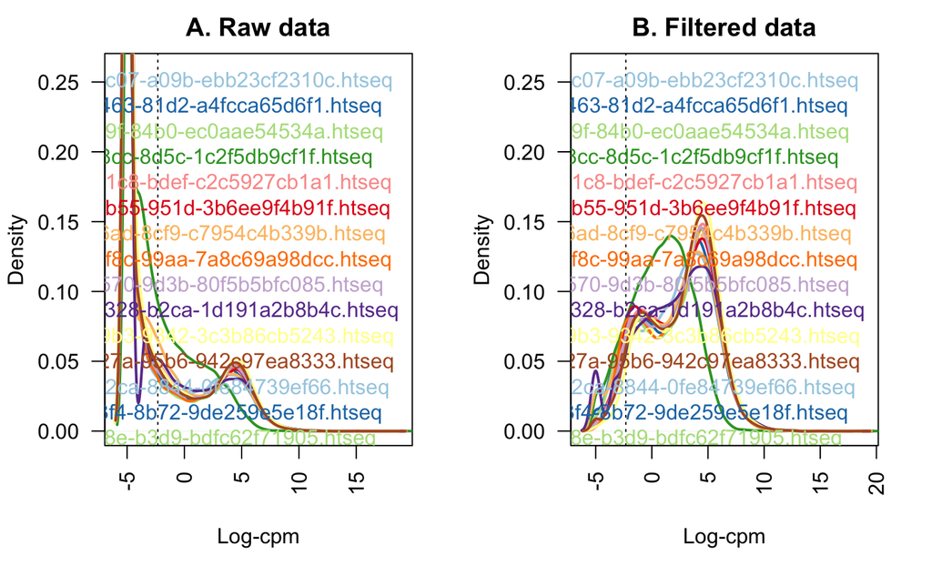

```r
for (i in 2:nsamples){
den <- density(lcpm[,i])
lines(den$x, den$y, col=col[i], lwd=2)
}
legend("topright", samplenames, text.col=col, bty="n")
```

## Normalising gene expression distributions

```r
x <- calcNormFactors(x, method = "TMM")
x$samples$norm.factors
```

```
 [1] 0.8247877 0.8701067 0.9744718 0.3338411 1.0672340 0.9853437 0.8355374 1.0685271 1.1041480
[10] 1.1621714 1.3190864 1.1616288 0.5656024 1.0079779 1.1311621 1.3455788 0.2548806 1.1728192
[19] 0.5164198 0.4158854 1.1552465 1.0977806 1.1538364 1.0380711 0.5054850 1.2962443 1.1705252
[28] 0.9900169 0.9259593 1.1222135 1.2985756 1.0598233 0.9471138 1.3391984 1.3043419 1.1144424
[37] 1.0697018 1.1921660 1.1054413 0.9399911 1.2384865 1.2243347 1.0760378 0.9933192 1.1164186
[46] 1.4176459 1.3689476 0.8989757 1.3130426 1.0789261 0.7851273 1.0110826 0.9751891 1.1994225
[55] 1.2667583 1.3476310 1.4869359 1.0917179 0.8579364 1.0468322
```

## Improve visualization by duplicating data then adjusting the counts

```r
x2 <- x
x2$samples$norm.factors <- 1
x2$counts[,1] <- ceiling(x2$counts[,1]*0.05)
x2$counts[,2] <- x2$counts[,2]*5
```

## Boxplot expression distribution of samples for unnormalised data

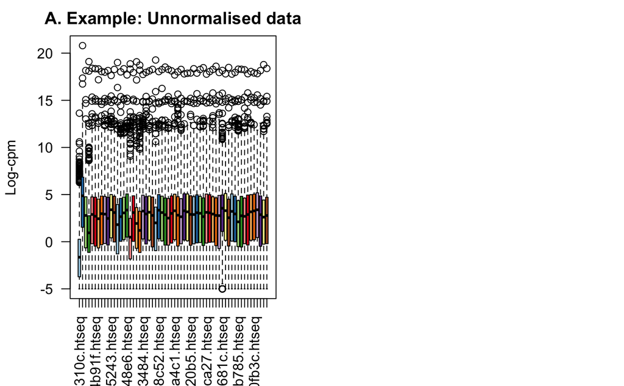

```r
par(mfrow=c(1,2))
lcpm <- cpm(x2, log=TRUE)
boxplot(lcpm, las=2, col=col, main="")
title(main="A. Example: Unnormalised data",ylab="Log-cpm")
```

```r
x2 <- calcNormFactors(x2)
x2$samples$norm.factors
```

```
 [1] 0.04889808 4.36314201 0.99857375 0.36344409 1.08814631 1.00048470 0.91165862 1.07196030
 [9] 1.10500025 1.21054683 1.28772624 1.16063702 0.60882746 1.04998828 1.13203522 1.31787908
[17] 0.28023587 1.16142488 0.53329090 0.46494919 1.14274272 1.09741972 1.16406362 1.04925131
[25] 0.51082602 1.30832124 1.17758030 1.00128465 0.97668711 1.11752935 1.28315406 1.05679584
[33] 0.99263908 1.36510564 1.33873108 1.14293994 1.10193770 1.21035319 1.10148876 0.97629109
[41] 1.25905436 1.25325781 1.12605092 1.02503014 1.11956858 1.41609997 1.38704078 0.91182127
[49] 1.31684398 1.09702295 0.85028060 1.03939580 1.01768934 1.20164571 1.27684217 1.35509884
[57] 1.51897054 1.10244902 0.85428854 1.05218206
```

## Boxplot expression distribution of samples for normalised data

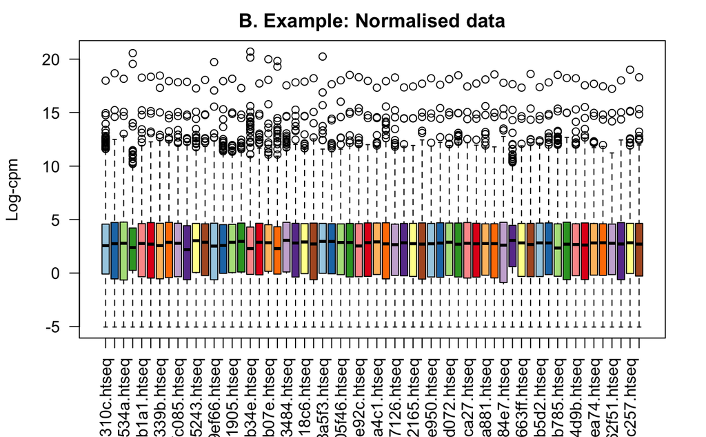

```r
lcpm <- cpm(x2, log=TRUE)
boxplot(lcpm, las=2, col=col, main="")
title(main="B. Example: Normalised data",ylab="Log-cpm")
```

## Unsupervised clustering of cells: make multi-dimensional scaling plot (MDS) to show simmilarities and dissimilarities between samples in an unsupervised manner

```r
lcpm <- cpm(x, log=TRUE)
par(mfrow=c(1,2))
col.group <- group
levels(col.group) <-  brewer.pal(nlevels(col.group), "Set1")
```

```
minimal value for n is 3, returning requested palette with 3 different levels
```

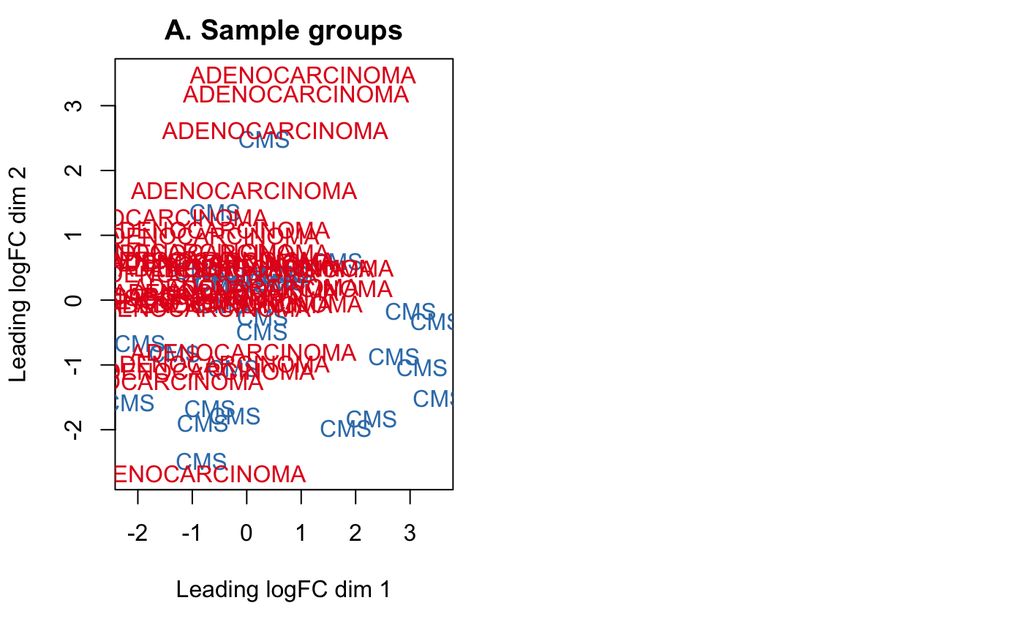

```r
col.group <- as.character(col.group)
plotMDS(lcpm, labels=group, col=col.group)
title(main="A. Sample groups")
```

## Make interactive using Glimma, html page will be generarted and opened in a browser if launch=TRUE

```r
library(Glimma)
glMDSPlot(lcpm, labels=paste(group, sep="_"),
          groups=x$samples[,c(1,2)], launch=TRUE)
```

# Differential expression analysis

## Creating a design matrix

```r
design <- model.matrix(~0+group)
colnames(design) <- gsub("group", "", colnames(design))
design
```

```
   ADENOCARCINOMA CMS
1               0   1
2               0   1
3               0   1
4               0   1
5               0   1
6               0   1
7               0   1
8               0   1
9               0   1
10              0   1
11              0   1
12              0   1
13              0   1
14              0   1
```

[output cut: 51 more lines]

## Contrasts for pairwise comparisons between cell populations

```r
library(limma)
contr.matrix <- makeContrasts(
   ADENOCARCINOMAvsCMS = ADENOCARCINOMA-CMS,
   levels = colnames(design))
contr.matrix
```

```
                Contrasts
Levels           ADENOCARCINOMAvsCMS
  ADENOCARCINOMA                   1
  CMS                             -1
```

## Remove heteroscedascity from count data

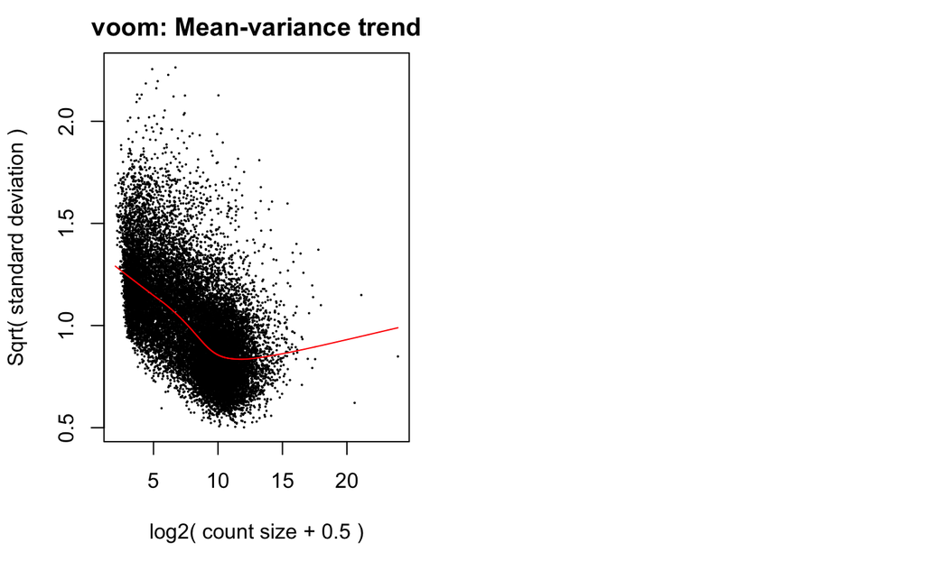

```r
 par(mfrow=c(1,2))
v <- voom(x, design, plot=TRUE)
```

```r
v
```

```
An object of class "EList"
$genes
```

|  | ENSEMBL | SYMBOL | TXCHROM |
| --- | --- | --- | --- |
| 1 | ENSG00000000005 | TNMD | chrX |
| 2 | ENSG00000000419 | DPM1 | chr20 |
| 3 | ENSG00000000457 | SCYL3 | chr1 |
| 4 | ENSG00000000460 | C1orf112 | chr1 |
| 5 | ENSG00000000938 | FGR | chr1 |

```
19100 more rows ...

$targets
```

|  | files | group | lib.size | norm.factors |
| --- | --- | --- | --- | --- |
| 9e8b528b-1172-4c07-a09b-ebb23cf2310c.htseq | 9e8b528b-1172-4c07-a09b-ebb23cf2310c.htseq.txt | CMS | 74292479 | 0.8247877 |
| bda1a9a4-a14f-4463-81d2-a4fcca65d6f1.htseq | bda1a9a4-a14f-4463-81d2-a4fcca65d6f1.htseq.txt | CMS | 31987425 | 0.8701067 |
| 5697212f-b3fd-479f-84b0-ec0aae54534a.htseq | 5697212f-b3fd-479f-84b0-ec0aae54534a.htseq.txt | CMS | 41835745 | 0.9744718 |
| 7f9a629b-12ed-48cc-8d5c-1c2f5db9cf1f.htseq | 7f9a629b-12ed-48cc-8d5c-1c2f5db9cf1f.htseq.txt | CMS | 37079196 | 0.3338411 |
| 15864159-be88-41c8-bdef-c2c5927cb1a1.htseq | 15864159-be88-41c8-bdef-c2c5927cb1a1.htseq.txt | CMS | 38748737 | 1.0672340 |

```
55 more rows ...

$E
                    Samples
Tags                 9e8b528b-1172-4c07-a09b-ebb23cf2310c.htseq
  ENSG00000000005.5                                  -0.6452887
  ENSG00000000419.11                                  4.0286248
  ENSG00000000457.12                                  3.9851413
  ENSG00000000460.15                                  0.7096682
  ENSG00000000938.11                                  1.1642341
                    Samples
Tags                 bda1a9a4-a14f-4463-81d2-a4fcca65d6f1.htseq
  ENSG00000000005.5                                   -2.829508
  ENSG00000000419.11                                   4.473258
  ENSG00000000457.12                                   2.886263
  ENSG00000000460.15                                   2.725081
  ENSG00000000938.11                                   2.134993
                    Samples
Tags                 5697212f-b3fd-479f-84b0-ec0aae54534a.htseq
  ENSG00000000005.5                                   -4.064736
  ENSG00000000419.11                                   4.069690
  ENSG00000000457.12                                   3.723166
  ENSG00000000460.15                                   2.937516
  ENSG00000000938.11                                   1.160230
                    Samples
Tags                 7f9a629b-12ed-48cc-8d5c-1c2f5db9cf1f.htseq
  ENSG00000000005.5                                   -1.820221
  ENSG00000000419.11                                   3.544018
  ENSG00000000457.12                                   4.437616
  ENSG00000000460.15                                   4.029445
  ENSG00000000938.11                                   3.674683
                    Samples
Tags                 15864159-be88-41c8-bdef-c2c5927cb1a1.htseq
  ENSG00000000005.5                                   -3.468722
  ENSG00000000419.11                                   4.049228
  ENSG00000000457.12                                   3.007011
  ENSG00000000460.15                                   2.235675
  ENSG00000000938.11                                   1.751829
                    Samples
Tags                 649b19e1-96e2-4b55-951d-3b6ee9f4b91f.htseq
```

[output cut: 423 more lines]

```
[1,] 0.4445163 0.5513897 0.5991062 0.3690418 0.4772951 0.4619017
[2,] 1.8390051 2.0430719 2.0559479 1.3656913 1.9465166 1.9026135
[3,] 1.1432791 1.6813825 1.8531617 0.8321907 1.3093027 1.2296981
[4,] 1.0184223 1.5124736 1.7195119 0.7611163 1.1586773 1.0909190
[5,] 0.8176537 1.1624749 1.3555422 0.6433334 0.9098613 0.8651225
19100 more rows ...

$design
  ADENOCARCINOMA CMS
1              0   1
2              0   1
3              0   1
4              0   1
5              0   1
55 more rows ...
```

## Apply voom precision weights to data

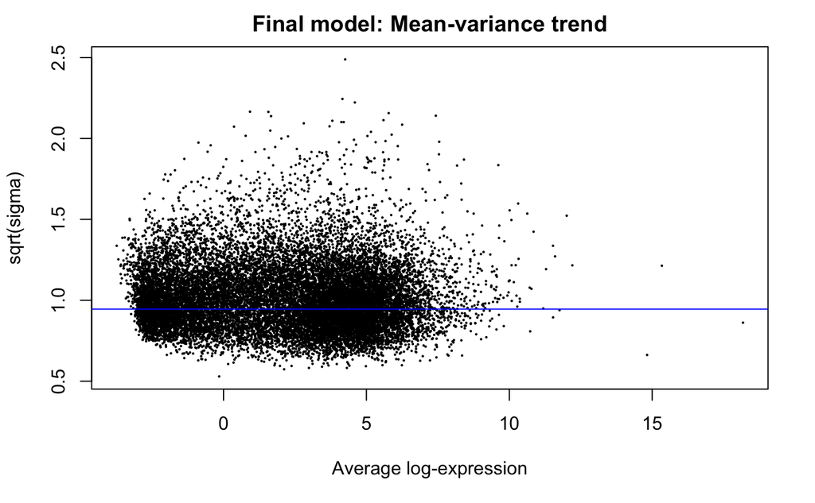

```r
vfit <- lmFit(v, design)
vfit <- contrasts.fit(vfit, contrasts=contr.matrix)
efit <- eBayes(vfit)
plotSA(efit, main="Final model: Mean-variance trend")
```

## Examine the number of DE genes

```r
summary(decideTests(efit))
```

```
       ADENOCARCINOMAvsCMS
Down                  1474
NotSig               15810
Up                    1821
```

## Set a minimum log-fold change(log-FC) of 1

```r
tfit <- treat(vfit, lfc=1)
dt <- decideTests(tfit)
summary(dt)
```

```
       ADENOCARCINOMAvsCMS
Down                     0
NotSig               19105
Up                       0
```

## Extract genes that are DE in multiple comparisons

```r
de.common <- which(dt[,1]!=0)
length(de.common)
```

```
[1] 0
```

```r
head(tfit$genes$SYMBOL[de.common], n=20)
```

```
character(0)
```

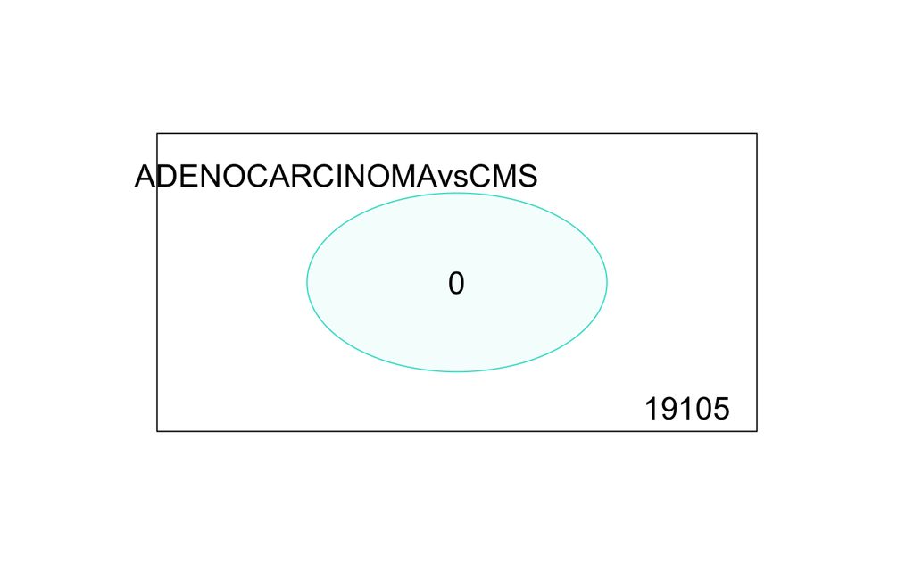

```r
vennDiagram(dt[,1], circle.col=c("turquoise", "salmon"))
```

## Extract and write results for comparisons of ADENOCARCINOMAvsCMS to a single output file

```r
write.fit(tfit, dt, file="results.txt")
```

## Examining individual DE genes from top to bottom

```r
ADENOCARCINOMA.vs.CMS <- topTreat(tfit, coef=1, n=Inf)
head(ADENOCARCINOMA.vs.CMS)
```

|  | ENSEMBL | SYMBOL | TXCHROM | logFC | AveExpr | t | P.Value | adj.P.Val |
| --- | --- | --- | --- | --- | --- | --- | --- | --- |
| ENSG00000183734.4 | ENSG00000183734 | ASCL2 | chr11 | 2.865714 | 4.4443348 | 3.725115 | 0.0002104473 | 1 |
| ENSG00000213937.3 | ENSG00000213937 | CLDN9 | chr16 | 2.641408 | -1.2524331 | 3.553146 | 0.0003648945 | 1 |
| ENSG00000041353.8 | ENSG00000041353 | RAB27B | chr18 | -2.314751 | 2.8336044 | -3.282792 | 0.0008416343 | 1 |
| ENSG00000251095.5 | ENSG00000251095 | NA | NA | -3.439676 | -2.2896305 | -3.222953 | 0.0010075530 | 1 |
| ENSG00000165863.15 | ENSG00000165863 | C10orf82 | chr10 | 2.759181 | -3.2822719 | 3.155506 | 0.0012310007 | 1 |
| ENSG00000170827.8 | ENSG00000170827 | CELP | chr9 | 3.418285 | -0.9891731 | 3.131993 | 0.0013194514 | 1 |

## Summarize results for genes using mean-difference plots that highlight differentially expressed genes

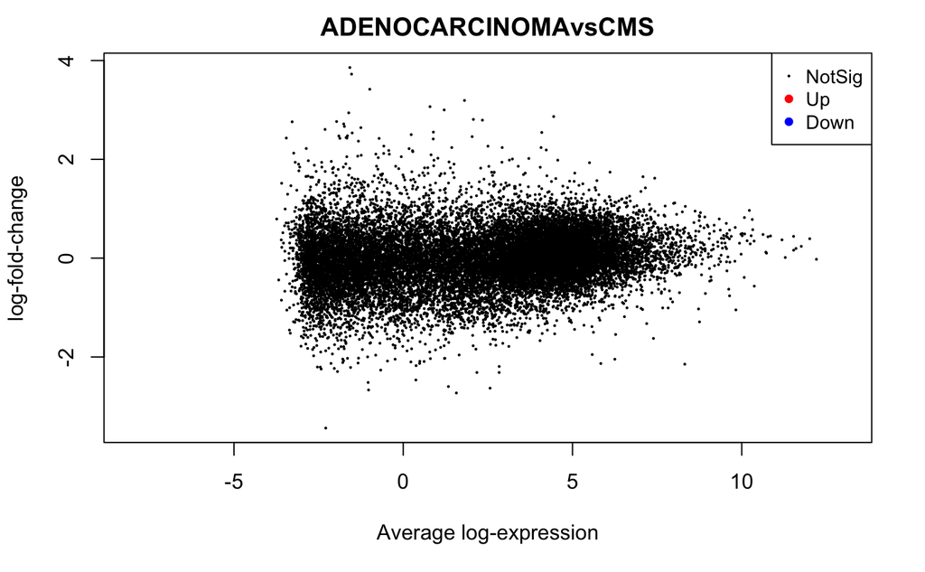

```r
plotMD(tfit, column=1, status=dt[,1], main=colnames(tfit)[1],
       xlim=c(-8,13))
```

## Make interactive mean-difference plot. To open html page in a browser make launch=TRUE

```r
glMDPlot(tfit, coef=1, status=dt, main=colnames(tfit)[1],
         side.main="ENSEMBL", counts=lcpm, groups=group, launch=TRUE)
```

## Make heatmap

Install heatmap.plus

[figure not shown]

```r
library(gplots)
library(heatmap.plus)
ADENOCARCINOMA.vs.CMS.topgenes <- ADENOCARCINOMA.vs.CMS$ENSEMBL[1:100]
i <- which(v$genes$ENSEMBL %in% ADENOCARCINOMA.vs.CMS.topgenes)
mycol <- colorpanel(1000,"blue","white","red")
#par("mar") OUTOUT SHOULD BE [1] 5.1 4.1 4.1 2.1
par(cex.main=0.8,mar=c(1,1,1,1))
heatmap.plus(lcpm[i,], col=bluered(20),cexRow=1,cexCol=0.2, margins = c(20,13), main = "HeatMap")
```